# Week 8 TinyText Lab-EWS

Emma Seiberlich

3/30/2021

# Background

Congratulations you’ve successfully transferred from being a NBA ‘quant’ scout to a consultant specializing in US national sentiment! You’ve been hired by a non-profit in secret to track the level of support nationally and regionally for the field of Data Science. The goal is to get a general idea of patterns associated with articles being written on the broad topic of Data Science (you can also choose to select a sub-topic). In doing so your data science team has decided to explore periodicals from around the country in a effort to track the relative positive or negative sentiment and word frequencies. Luckily your team has access to a world class library search engine call LexusNexus (NexusUni) that provides access to newspapers from around the country dating back decades. You’ll first need to decided what words you want to track and what time might be interesting to begin your search.

You’ll need to select several newspapers from different regions in the country limiting the search to 100 articles from each paper, run sentiment analysis with each newspaper serving as a corpus and then compare the level of positive or negative connotation associated with the outcomes. Also, run tf-idf on each corpus (newspapers) and work to compare the differences between the distributions (5 to 6 newspapers should be fine)

Your main goal (and the goal of all practicing data scientists!) is to translate this information into action. What patterns do you see, why do you believe this to be the case? What additional information might you want? Be as specific as possible, but keep in mind this is an initial exploratory effort…more analysis might be needed…but the result can and should advise the next steps you present to the firm.

Please submit a cleanly knitted HTML file describing in detail the steps you took along the way, the results of your analysis and most importantly the implications/next steps you would recommend. You will report your final results and recommendations next week in class. This will be 5 minutes per group.

You will need also need to try to collaborate within your group via a GitHub repo, if you choose it would be fine to assign 1 or 2 regions/newspapers per group member, that can then be added to the repo. Create a main repo, everyone should work in this repo and submit independently using branching/pull requests. If you want to try to use pull request to combine everyone’s work into a final project, please do so, but it’s not a requirement. Select a repo owner that sets up access (push access) for the week, we will rotate owners next week. Also, submit a link to your the GitHub repo (every group member can submit the same link).

For our analysis, I have chosen to extract articles from NexusUni that include ‘data science’ from 5 US cities– Philadelphia, New York City, Chicago, Dayton, and Los Angeles.

## The Philadelphia Inquirer– ‘data science’

For this section, 25 articles were included.

```r
PHLInquirer<- read_lines("Files (25).txt")
PHLInquirer<- tibble(PHLInquirer)
PHLInquirer$PHLInquirer<- as.character(PHLInquirer$PHLInquirer) #into large character
PHLInquirer <- PHLInquirer %>%
  unnest_tokens(word, PHLInquirer)%>%
  anti_join(stop_words)%>%
  count(word, sort=TRUE)
```

## Sentiment Analysis- Philadelphia

```r
PHLInqAFFIN<- PHLInquirer %>%
  inner_join(get_sentiments("afinn"))
PHLInqNRC<- PHLInquirer %>%
  inner_join(get_sentiments("nrc"))
PHLInqBING<- PHLInquirer %>%
  inner_join(get_sentiments("bing"))
table(PHLInqBING$sentiment)
```

```
##
## negative positive
##      196      169
```

```r
table(PHLInqNRC$sentiment)
```

```
##
##        anger anticipation      disgust         fear          joy     negative
##           74          132           49          111           89          209
##     positive      sadness     surprise        trust
##          362           89           54          217
```

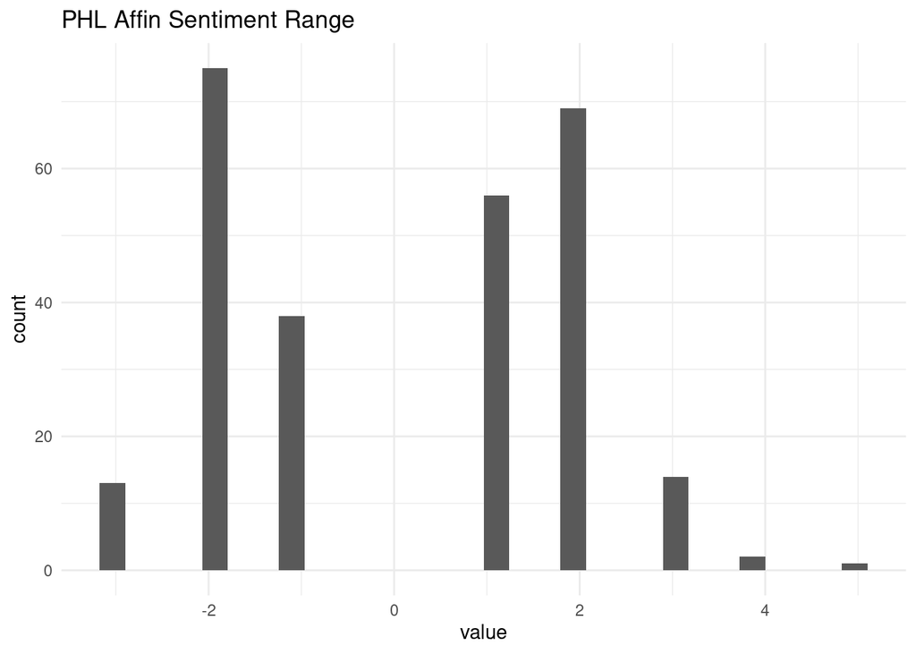

```r
ggplot(data = PHLInqAFFIN,
       aes(x=value)
)+
  geom_histogram()+
  ggtitle("PHL Affin Sentiment Range")+
  theme_minimal()
```

## New York Times- “data science”

```r
NYT<- read_lines("NYT 40.txt")
NYT<- tibble(NYT)
NYT$NYT<- as.character(NYT$NYT) #into large character

NYT <- NYT %>%
  unnest_tokens(word, NYT)%>%
  anti_join(stop_words)%>%
  count(word, sort=TRUE)
```

## Sentiment Analysis- New York

```r
NYTaffin<- NYT %>%
  inner_join(get_sentiments("afinn"))
NYTnrc<- NYT %>%
  inner_join(get_sentiments("nrc"))
NYTbing<- NYT %>%
  inner_join(get_sentiments("bing"))
table(NYTbing$sentiment)
```

```
##
## negative positive
##      382      322
```

```r
table(NYTnrc$sentiment)
```

```
##
##        anger anticipation      disgust         fear          joy     negative
##          156          224           97          210          169          385
##     positive      sadness     surprise        trust
##          580          149          107          359
```

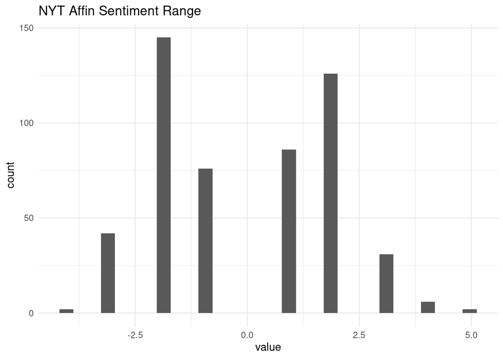

```r
ggplot(data = NYTaffin,
       aes(x=value)
)+
  geom_histogram()+
  ggtitle("NYT Affin Sentiment Range")+
  theme_minimal()
```

## Chicago Daily Herald– “data science”

```r
chicago<- read_lines("chicago 40.txt")
chicago<- tibble(chicago)
chicago$chicago<- as.character(chicago$chicago) #into large character

chicago <- chicago %>%
  unnest_tokens(word, chicago)%>%
  anti_join(stop_words)%>%
  count(word, sort=TRUE)
```

## Chicago Sentiment Analysis

```r
chicagoAFINN<- chicago %>%
  inner_join(get_sentiments("afinn"))
chicagoNRC<- chicago %>%
  inner_join(get_sentiments("nrc"))
chicagoBING<- chicago %>%
  inner_join(get_sentiments("bing"))
table(chicagoBING$sentiment)
```

```
##
## negative positive
##      160      251
```

```r
table(chicagoNRC$sentiment)
```

```
##
##        anger anticipation      disgust         fear          joy     negative
##           79          179           44           96          123          174
##     positive      sadness     surprise        trust
##          453           81           72          276
```

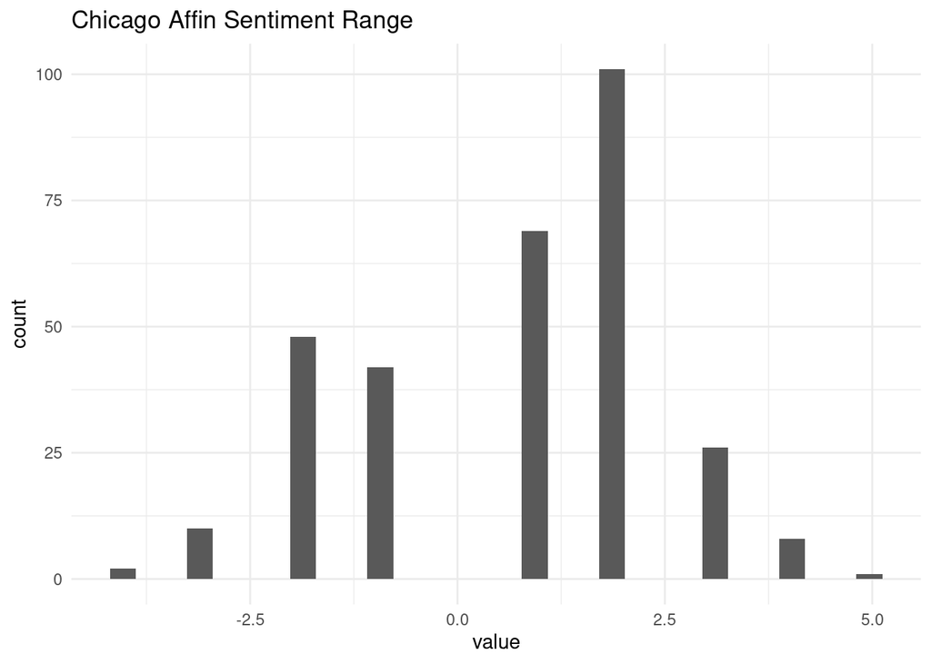

```r
ggplot(data = chicagoAFINN,
       aes(x=value)
)+
  geom_histogram()+
  ggtitle("Chicago Affin Sentiment Range")+
  theme_minimal()
```

## Dayton Daily News– “data science”

```r
dayton<- read_lines("dayton 50.txt")
dayton<- tibble(dayton)
dayton$dayton<- as.character(dayton$dayton) #into large character

dayton <- dayton %>%
  unnest_tokens(word, dayton)%>%
  anti_join(stop_words)%>%
  count(word, sort=TRUE)
```

## Dayton Sentiment Analysis

```r
daytonAFINN<- dayton %>%
  inner_join(get_sentiments("afinn"))
daytonNRC<- dayton %>%
  inner_join(get_sentiments("nrc"))
daytonBING<- dayton %>%
  inner_join(get_sentiments("bing"))
table(daytonBING$sentiment)
```

```
##
## negative positive
##      208      285
```

```r
table(daytonNRC$sentiment)
```

```
##
##        anger anticipation      disgust         fear          joy     negative
##          103          179           59          129          137          236
##     positive      sadness     surprise        trust
##          526           95           83          303
```

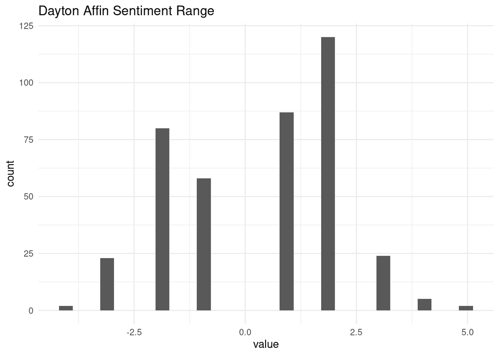

```r
ggplot(data = daytonAFINN,
       aes(x=value)
)+
  geom_histogram()+
  ggtitle("Dayton Affin Sentiment Range")+
  theme_minimal()
```

## Los Angeles Times– “data science”

```r
la_times <- read_lines("la_times7.txt")

la_times <- tibble(la_times)


la_times <- la_times %>%
  unnest_tokens(word, la_times)%>%
  anti_join(stop_words)%>%
  count(word, sort=TRUE)
```

## Los Angeles Sentiment Analysis

```r
la_sentiment_affin <- la_times %>%
  inner_join(get_sentiments("afinn"))#using a inner join to match words and add the sentiment variable
la_sentiment_nrc <- la_times %>%
  inner_join(get_sentiments("nrc"))
la_sentiment_bing <- la_times %>%
  inner_join(get_sentiments("bing"))
table(la_sentiment_bing$sentiment)
```

```
##
## negative positive
##      126      109
```

```r
table(la_sentiment_nrc$sentiment)
```

```
##
##        anger anticipation      disgust         fear          joy     negative
##           55           84           38           78           68          142
##     positive      sadness     surprise        trust
##          237           64           42          137
```

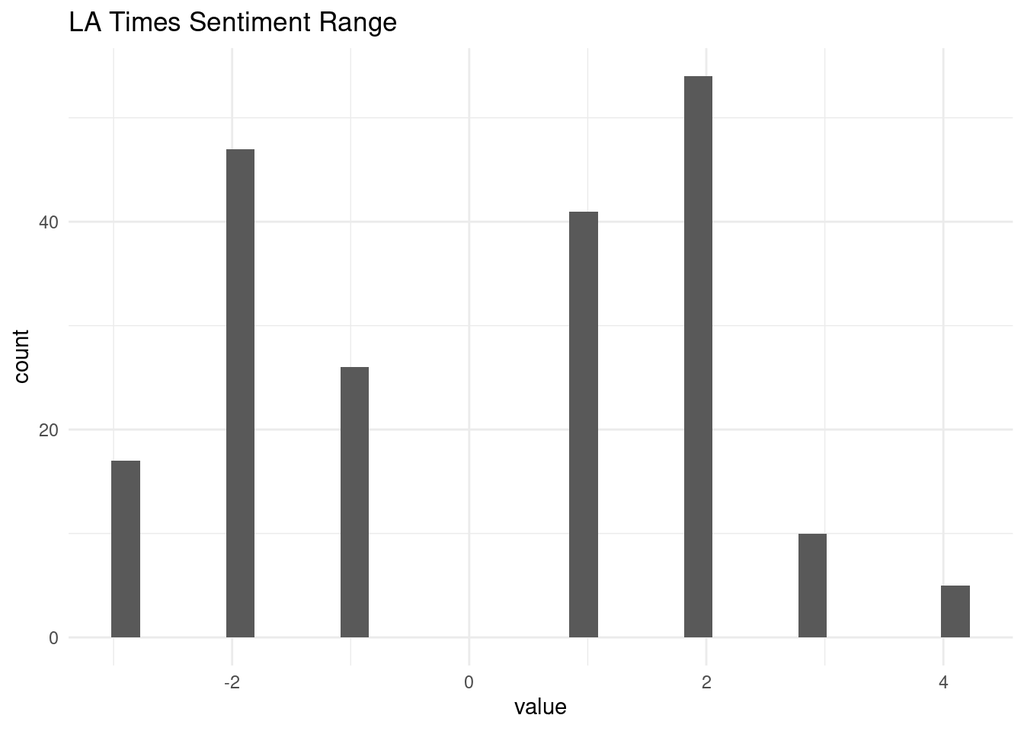

```r
ggplot(data = la_sentiment_affin,
       aes(x=value)
        )+
  geom_histogram()+
  ggtitle("LA Times Sentiment Range")+
  theme_minimal()
```

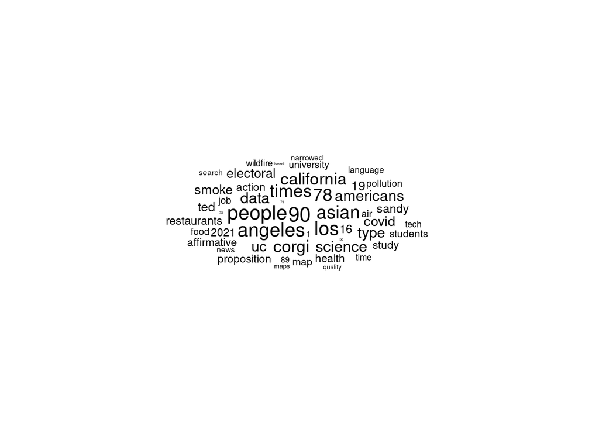

```r
# using ggwordcloud package
set.seed(42)
ggplot(la_times[1:50,], aes(label = word, size = n)
       ) +
  geom_text_wordcloud() +
  theme_minimal()
```

```r
PHLraw<- as_tibble(read_lines("Files (25).txt"))
NYTraw<- as_tibble(read_lines("NYT 40.txt"))
Chicagoraw<- as_tibble(read_lines("chicago 40.txt"))
Daytonraw<- as_tibble(read_lines("dayton 50.txt"))
la_times_raw <- as_tibble(read_lines("la_times7.txt"))
```

```r
data_prep <- function(x,y,z){
  i <- as_tibble(t(x))
  ii <- unite(i,"text",y:z,remove = TRUE,sep = "")
}

PHLprep<- data_prep(PHLraw,'V1','V1738')
```

```
## Note: Using an external vector in selections is ambiguous.
## ℹ Use `all_of(y)` instead of `y` to silence this message.
## ℹ See <https://tidyselect.r-lib.org/reference/faq-external-vector.html>.
```

```
## Note: Using an external vector in selections is ambiguous.
## ℹ Use `all_of(z)` instead of `z` to silence this message.
## ℹ See <https://tidyselect.r-lib.org/reference/faq-external-vector.html>.
```

```r
NYTprep<- data_prep(NYTraw, 'V1', 'V3085')
Chicagoprep<- data_prep(Chicagoraw, 'V1','V1775')
Daytonprep<- data_prep(Daytonraw, 'V1', 'V2913')
LAprep <- data_prep(la_times_raw, 'V1', 'V707')
cities <- c("Philadelphia","NYC","Chicago", "Dayton", "Los Angeles")


tf_idf_text <- tibble(cities,text=t(tibble(PHLprep,
                                           NYTprep,
                                           Chicagoprep,
                                           Daytonprep,
                                           LAprep,.name_repair = "universal")))
```

```
## * text -> text...1
## * text -> text...2
## * text -> text...3
## * text -> text...4
## * text -> text...5
```

```r
class(tf_idf_text)
```

```
## [1] "tbl_df"     "tbl"        "data.frame"
```

```r
word_count <- tf_idf_text %>%
  unnest_tokens(word, text) %>%
  count(cities, word, sort = TRUE)

total_words <- word_count %>%
  group_by(cities) %>%
  summarize(total = sum(n))

news_words <- left_join(word_count, total_words)
head(news_words,10)
```

```
## # A tibble: 10 x 4
##    cities  word      n total
##    <chr>   <chr> <int> <int>
##  1 NYC     the    3153 63977
##  2 Dayton  the    1776 42282
##  3 NYC     of     1746 63977
##  4 NYC     a      1639 63977
##  5 NYC     and    1626 63977
##  6 NYC     to     1611 63977
##  7 Chicago the    1434 31000
##  8 NYC     in     1391 63977
##  9 Dayton  to     1269 42282
## 10 Dayton  and    1248 42282
```

```r
#View(news_words)

news_words2 <- news_words %>%
  bind_tf_idf(word, cities, n)

head(news_words2,10)
```

```
## # A tibble: 10 x 7
##    cities  word      n total     tf   idf tf_idf
##    <chr>   <chr> <int> <int>  <dbl> <dbl>  <dbl>
##  1 NYC     the    3153 63977 0.0493     0      0
##  2 Dayton  the    1776 42282 0.0420     0      0
##  3 NYC     of     1746 63977 0.0273     0      0
##  4 NYC     a      1639 63977 0.0256     0      0
##  5 NYC     and    1626 63977 0.0254     0      0
##  6 NYC     to     1611 63977 0.0252     0      0
##  7 Chicago the    1434 31000 0.0463     0      0
##  8 NYC     in     1391 63977 0.0217     0      0
##  9 Dayton  to     1269 42282 0.0300     0      0
## 10 Dayton  and    1248 42282 0.0295     0      0
```

```r
#View(news_words2)
```